# 1. Wprowadzenie

W niniejszym projekcie dokonano analizy autokorelacji oraz sezonowości w danych dotyczących cen zamknięcia spółki Alphabet Inc. Analizowano następujące szeregi:

- 5-minutowe logarytmiczne stopy zwrotu
- wartości bezwględne 5-minutowych logarytmicznych stóp zwrotu
- kwadraty 5-minutowych logarytmicznych stóp zwrotu

z okresu od 14 kwietnia 2023 do 4 czerwca 2023 roku. Do tego celu wykorzystano analizę korelogramu, a także metody analizy spektralnej: periodogram oraz filtry górno- i dolnoprzepustowy w celu zbadania składowych krótko- oraz długookresowych szeregu.

# 2. Wstępna analiza danych

Analizowane dane zaweirają informacje o cenach zamknięcia spółki Google (Alphabet Inc) i były gromadzone w odstępach 5 minutowych każdego dnia roboczego w godzinach działania giełdy - pomiędzy godziną 9:30 a 16. Na podstawie danych obliczono 5-minutowe logarytmiczne stopy zwrotu, a także ich wartości bezwzględne oraz kwadraty. Ogółem każdy szereg zawiera 2729 obserwacji.

Poniżej przedstawiono podstawowe statystyki opisowe oraz wykresy wspomnianych szeregów. Można z nich wywnioskować między innymi, że transformacja szeregu stóp poprzed podniesienie do kwadratu sprawiła, że stopy o niskich wartościach zostały jeszcze bardziej wygaszone, zaś ponadprzeciętnie wysokie wartości zostały dodatkowo wzmocnione.

```python
import pandas as pd
import numpy as np
from datetime import datetime
import statsmodels.api as sm

from matplotlib import pyplot as plt
import seaborn as sns
sns.set_theme(style="whitegrid")

import warnings
warnings.filterwarnings("ignore")
```

```python
def split_date(date_text, time_text):
    # zamiana daty i czasu wyrażonych jako łańcuchy cyfr na daty oraz godziny
    date_text, time_text = str(int(date_text)), str(int(time_text))
    year, mth, day = int(date_text[:4]), int(date_text[4:6]), int(date_text[-2:])
    hour, mins = int(time_text[:2]), int(time_text[2:4])
    # odejmij 6 aby przejść z czasu CET na Eastern US
    hour -= 6
    date = datetime(year, mth, day, hour, mins, 0, 0)
    return date


def process_stock_data(data):
    df = data.copy()
    # wybranie tylko istotnych kolumn
    col_names = ["<DATE>", "<TIME>", "<CLOSE>"]
    df = df[col_names]
    # zmiana nazw kolumn
    df.columns = ["date", "time", "close"]
    # połączenie kolumny z datą i czasem w jedną
    df["date"] = df.apply(lambda x: split_date(x["date"], x["time"]), axis=1)
    df.index = pd.DatetimeIndex(df["date"])
    df.drop(columns=["date", "time"], inplace=True)
    # logarytmiczne stopy zwrotu
    df["log_return"] = np.log(df["close"]) - np.log(df["close"].shift(1))
    df["abs_log_return"] = np.abs(df["log_return"])
    df["sqrt_log_return"] = df["log_return"] ** 2
    return df

google_df = pd.read_csv("googl.us.txt")
df = process_stock_data(google_df)
df.head()
```

| date | close | log_return | abs_log_return | sqrt_log_return |
| --- | --- | --- | --- | --- |
| 2023-04-14 09:30:00 | 107.4086 | NaN | NaN | NaN |
| 2023-04-14 09:35:00 | 107.8100 | 0.003730 | 0.003730 | 1.391413e-05 |
| 2023-04-14 09:40:00 | 107.7700 | -0.000371 | 0.000371 | 1.377092e-07 |
| 2023-04-14 09:45:00 | 107.8500 | 0.000742 | 0.000742 | 5.506326e-07 |
| 2023-04-14 09:50:00 | 107.9500 | 0.000927 | 0.000927 | 8.589288e-07 |

```python
df = df.dropna()
df.describe()
```

|  | close | log_return | abs_log_return | sqrt_log_return |
| --- | --- | --- | --- | --- |
| count | 2729.000000 | 2729.000000 | 2729.000000 | 2.729000e+03 |
| mean | 113.286078 | 0.000055 | 0.001199 | 3.971438e-06 |
| std | 8.122678 | 0.001992 | 0.001592 | 2.878384e-05 |
| min | 102.925000 | -0.027849 | 0.000000 | 0.000000e+00 |
| 25% | 105.570000 | -0.000770 | 0.000365 | 1.332038e-07 |
| 50% | 108.345000 | 0.000056 | 0.000852 | 7.259858e-07 |
| 75% | 122.590000 | 0.000905 | 0.001530 | 2.339695e-06 |
| max | 126.170000 | 0.028772 | 0.028772 | 8.278416e-04 |

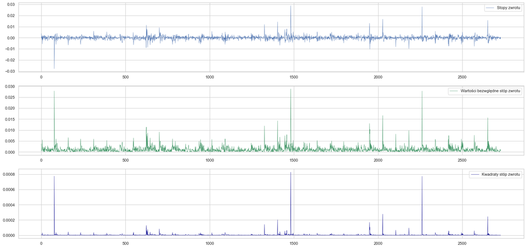

```python
f, ax = plt.subplots(3, 1, figsize=(25, 12))
ax[0].plot(range(len(df)), df["log_return"], linewidth=.6, label = "Stopy zwrotu")
ax[0].legend()
ax[1].plot(range(len(df)), df["abs_log_return"], linewidth=.6, label = "Wartości bezwględne stóp zwrotu", color="seagreen")
ax[1].legend(loc="upper right")
ax[2].plot(range(len(df)), df["sqrt_log_return"], linewidth=.6, label = "Kwadraty stóp zwrotu", color="darkblue")
ax[2].legend()
plt.show()
```

# 3. Korelogram

Ponieważ dane były gromadzone w odstępach co 5 minut każdego dnia w czasie działania giełdy, każdy dzień w szeregu posiada 78 obserwacji.

```python
# liczba obserwacji przypadająca na jeden dzień (jedną sesję)
T = df[(df.index >= "2023-04-17 09:30:00") & (df.index < "2023-04-18 09:30:00")].shape[0]
T
```

```
78
```

Na poniższych wykresach przedstawiono trzy korelogramy - każdy dla jednego z analizowanych szeregów. Pierwszy korelogram przedstawia wartości korelacji pomiędzy stopami zwrotu oraz ich opóźnionymi wartościami. Wykres wskazuje na istotność korelacji dla niewielkiej liczby opóźnień. Są to opóźnienia 1, 78, 80, 237, 310 oraz 381. Oscylują one w okolicach wartości będących wielokrotnością liczby 78, co oznaczałoby, że o zbliżonych porach dnia występują podobne ruchy cen. Dodatkowo, aktualna stopa zwrotu jest pozytywnie skorelowana ze stopą sprzed 5 minut. Korelacje te, nawet jeśli istotne, są jednak niewielkie i nie przekraczają na moduł wartości 0,08.

Ostatni wykres dotyczący kwadratów stóp zwrotu pozwolił w wyraźny sposób zaobserwować dzienną sezonowość danych i wygasił korelacje dla pozostałych opóźnień. Wszystkie istotne piki są wielokrotnością 78, co oznacza, że kwadraty stóp zwrotu są wysoko skorelowane z kwadratami zmian cen z poprzednich dni, które miały miejsce o tych samych godzinach. Istotna jest także korelacja dla opóźnienia 1 - wielkości stóp następujące jedna po drugiej są ze sobą poytywnie skorelowane.

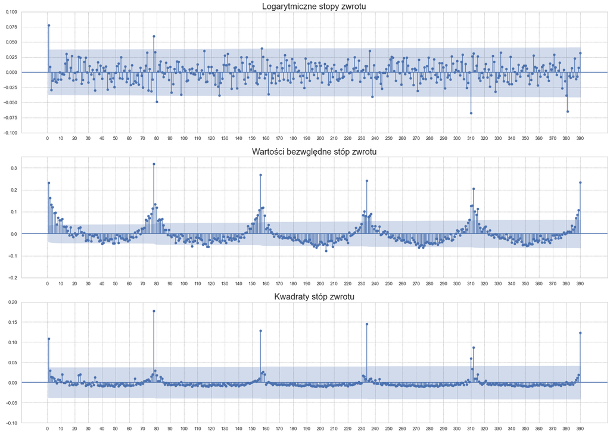

```python
fig, ax = plt.subplots(3, 1, figsize=(25, 18))

# korelogram stóp
sm.graphics.tsa.plot_acf(df["log_return"].dropna(), lags=5*T, ax=ax[0], zero=False)
ax[0].grid(which="major", color="grey", linestyle="--", linewidth=0.5)
ax[0].set_xticks(np.arange(0, 5 * T + 1, 10))
ax[0].set_ylim(-.1, .1)
ax[0].set_title('Logarytmiczne stopy zwrotu', size=20)

# korelogram wartości bezwzględnych stóp
sm.graphics.tsa.plot_acf(df["abs_log_return"].dropna(), lags=5*78, ax=ax[1], zero=False)
ax[1].grid(which="major", color="grey", linestyle="--", linewidth=0.5)
ax[1].set_xticks(np.arange(0, 5 * T + 1, 10))
ax[1].set_ylim(-.2, .35)
ax[1].set_title('Wartości bezwględne stóp zwrotu', size=20)

# korelogram kwadratów stóp
sm.graphics.tsa.plot_acf(df["sqrt_log_return"].dropna(), lags=5*78, ax=ax[2], zero=False)
ax[2].grid(which="major", color="grey", linestyle="--", linewidth=0.5)
ax[2].set_xticks(np.arange(0, 5 * T + 1, 10))
ax[2].set_ylim(-.1, .2)
ax[2].set_title("Kwadraty stóp zwrotu", size=20)

plt.show()
```

# 4. Periodogram

W dziedzinie analizy szeregów czasowych jaką jest analiza spektralna, szeregi czasowe postrzegamy jako sumę fal cosinusów oraz sinusów o różnych amplitudach i częstotliwościach. Jednym z celów analizy spektralnej jest zidentyfikowanie istotnych częstotliwości (okresów) w obserwowanym procesie. Podstawowym narzędziem wykorzystywanym do tego celu jest periodogram. Wykresy periodogramu przedstawiają wielkość znaczenia różnych częstotliwości, które mogą wyjaśniać przebieg oscylacji obserwowanych danych.

W niniejszej części projektu przedstawiono periodogramy dla każdego z analizowanych szeregów. Z ich wykorzystaniem zbadano sezonowości omawianych danych. Na wykresie periodogramu można zobaczyć, jak moc sygnału rozkłada się w różnych częstotliwościach. Na osi poziomej przedstawiane są różne wartości częstotliwości (w Hz), zaś na osi pionowej przedstawiana jest wartość mocy dla danej częstotliwości. Jeśli dana częstotliwość dominuje w badanym procesie, można ją zidentyfikować na wykresie periodogramu jako pikowe wartości mocy.

## 4.1. Stopy zwrotu

```python
# wyznaczenie transformaty Fouriera
returns = df['log_return'].copy().to_numpy()
returns_fft = np.fft.fft(returns)

# obliczanie gęstości spektralnej (periodogramu)
power_spectrum = np.abs(returns_fft) ** 2

# wyznaczanie częstotliwości (w Hz)
# częstotliwość wyrażamy jako 1 / 300s, ponieważ dane gromadzono co 5 min.
n = len(df)
freq = np.linspace(0, 1 / (5 * 60), n)
```

### 4.1.1. Wykres peridogramu

Peridogram dla stóp zwrotu jest bardzo zaszumiony i trudny do zinterpretowania. Z uwagi na brak jednoznacznych pików, peridogram wskazuje na rozproszenie wartości mocy na całym zakresie częstotliwości, bez żadnych wyraźnych wzorców. Świadczy to o dużej losowości stóp zwrotu i niezależności kolejnych obserwacji. Z drugiej strony na periodogramie widoczne są miejsca zagęszczenia pików, które wynikają z charakteru przeciekania sąsiadujących częstotliwości podczas obliczania dyskretnej transformaty Fourier'a. Możliwe jest, że te obszary wskazują na dominujące częstotliwości.

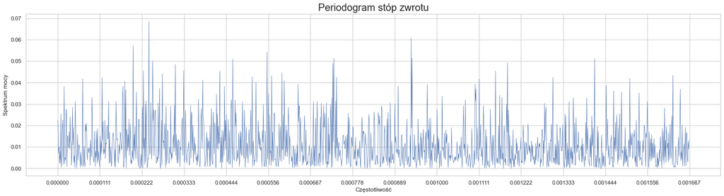

```python
fig, ax = plt.subplots(figsize=(25, 6))
plt.plot(freq[:n//2], power_spectrum[:n//2], linewidth=0.7)
plt.xticks(np.arange(0, 1 / (5 * 60) / 2, 1 / (5 * 60 * 10) / 3))
plt.xlabel('Częstotliwość')
plt.ylabel('Spektrum mocy')
plt.title('Periodogram stóp zwrotu', size=20)
plt.show()
```

### 4.1.2. Częstotliwości dominujące

Z powyższego periodogramu pobrano 10 dominujących częstotliwości (charakeryzujących się najwyższym spektrum mocy). Następnie częstotliwości odpowiednio przekształcono w celu otrzymania wielkości dominujących okresów. Na tej podstawie możemy określić okresy, w których występują regularne wzorce. Pięć najważniejszych okresów, które zidentyfikowano na periodogramie (po zaokrągleniu do najbliższych 5 minut) to:

```python
# wyszukiwanie indeksów o największej gęstości spektralnej
max_indices = np.argsort(power_spectrum[:n//2])[-10:]
max_indices = np.flip(max_indices)

# znajdowanie częstotliwości odpowiadających dominującym pikom
dominant_frequencies = freq[max_indices]

for i, freq_index in enumerate(max_indices):
    power_value = power_spectrum[freq_index]
    print(f"Częstotliwość dominująca {i+1}: {dominant_frequencies[i]:.5f}; "
          f"Okres: {1 / dominant_frequencies[i] / 60 / 60:.3f} godz. = {1 / dominant_frequencies[i] / 60:.3f} min.")
```

```
Częstotliwość dominująca 1: 0.00024; Okres: 1.154 godz. = 69.239 min.
Częstotliwość dominująca 2: 0.00093; Okres: 0.298 godz. = 17.877 min.
Częstotliwość dominująca 3: 0.00020; Okres: 1.395 godz. = 83.681 min.
Częstotliwość dominująca 4: 0.00055; Okres: 0.503 godz. = 30.177 min.
Częstotliwość dominująca 5: 0.00093; Okres: 0.297 godz. = 17.830 min.
Częstotliwość dominująca 6: 0.00073; Okres: 0.381 godz. = 22.886 min.
Częstotliwość dominująca 7: 0.00142; Okres: 0.196 godz. = 11.769 min.
Częstotliwość dominująca 8: 0.00046; Okres: 0.601 godz. = 36.085 min.
Częstotliwość dominująca 9: 0.00025; Okres: 1.109 godz. = 66.537 min.
Częstotliwość dominująca 10: 0.00119; Okres: 0.234 godz. = 14.047 min.
```

## 4.2. Wartości bezwględne stóp zwrotu

Peridogram dla wartości bezwględnych stóp zwrotu, w przeciewiństwie do peridogramu powyżej, wskazuje już kilka wyraźnych pików, które wyraźnie gasną wraz ze wzrostem częstotliwości. Oznacza to, że najbardziej dominujące wzorce występują wsród niższych częstotliwości - dla okresów powyżej jednej godziny (1 / 0.0003 /60 / 60 to prawie godzina). Poniżej odczytano dominujące okresy.

```python
1 / 0.0003 /60 / 60
```

```
0.9259259259259259
```

```python
# wyznaczenie transformaty Fouriera
abs_returns = df['abs_log_return'].copy().to_numpy()
abs_returns_fft = np.fft.fft(abs_returns)

# obliczanie gęstości spektralnej (periodogramu)
abs_power_spectrum = np.abs(abs_returns_fft) ** 2

# wyznaczanie częstotliwości (w Hz)
# częstotliwość wyrażamy jako 1 / 300s, ponieważ dane gromadzono co 5 min.
n = len(df)
freq = np.linspace(0, 1 / (5 * 60), n)
```

### 4.2.1. Wykres periodogramu

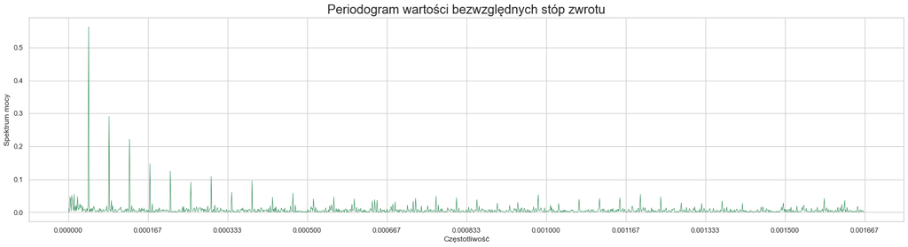

```python
fig, ax = plt.subplots(figsize=(25, 6))
plt.plot(freq[1:n//2], abs_power_spectrum[1:n//2], linewidth=0.7, color="seagreen")
plt.xticks(np.arange(0, 1 / (5 * 60) / 2, 1 / (5 * 60 * 10) / 2))
plt.xlabel('Częstotliwość')
plt.ylabel('Spektrum mocy')
plt.title('Periodogram wartości bezwzględnych stóp zwrotu', size=20)
plt.show()
```

### 4.2.2. Częstotliwości dominujące

Z powyższego periodogramu pobrano 10 dominujących częstotliwości (charakeryzujących się najwyższym spektrum mocy). Następnie częstotliwości odpowiednio przekształcono w celu otrzymania wielkości dominujących okresów w danych. Na tej podstawie możemy określić okresy, w których występują regularne wzorce. Pięć najważniejszych okresów to w przybliżeniu:

```python
max_indices = np.argsort(abs_power_spectrum[1:n//2])[-10:]
max_indices = np.flip(max_indices)

# znajdowanie częstotliwości odpowiadających dominującym pikom
dominant_frequencies = freq[max_indices]

for i, freq_index in enumerate(max_indices):
    power_value = abs_power_spectrum[freq_index]
    print(f"Częstotliwość dominująca {i+1}: {dominant_frequencies[i]:.5f}; "
          f"Okres: {1 / dominant_frequencies[i] / 60 / 60:.3f} godz. = {1 / dominant_frequencies[i] / 60:.3f} min.")
```

```
Częstotliwość dominująca 1: 0.00004; Okres: 6.686 godz. = 401.176 min.
Częstotliwość dominująca 2: 0.00008; Okres: 3.295 godz. = 197.681 min.
Częstotliwość dominująca 3: 0.00013; Okres: 2.186 godz. = 131.154 min.
Częstotliwość dominująca 4: 0.00017; Okres: 1.635 godz. = 98.129 min.
Częstotliwość dominująca 5: 0.00021; Okres: 1.307 godz. = 78.391 min.
Częstotliwość dominująca 6: 0.00030; Okres: 0.932 godz. = 55.902 min.
Częstotliwość dominująca 7: 0.00038; Okres: 0.724 godz. = 43.439 min.
Częstotliwość dominująca 8: 0.00026; Okres: 1.088 godz. = 65.263 min.
Częstotliwość dominująca 9: 0.00034; Okres: 0.815 godz. = 48.889 min.
Częstotliwość dominująca 10: 0.00047; Okres: 0.592 godz. = 35.521 min.
```

## 4.3. Kwadraty stóp zwrotu

Peridogram dla kwadratów sóp zwrotu wskazuje dominujące częstotliwości podobnie do poprzedniego periodogramu. Moce pików nie gasną tak bardzo jak dla wartości bezwględnych stóp (chociaż skala na osi Y jest dużo mniejsza). Dużo wyraźniej widać dla jakich częstotliwości szereg wykazuje cykliczne wzorce, ponieważ pozostałe obszary są bardzo wygaszone. Poniżej odczytano częstotliwości dominujące w szeregu.

```python
# wyznaczenie transformaty Fouriera
sqrt_returns = df['sqrt_log_return'].copy().to_numpy()
sqrt_returns_fft = np.fft.fft(sqrt_returns)

# obliczanie gęstości spektralnej (periodogramu)
sqrt_power_spectrum = np.abs(sqrt_returns_fft) ** 2
```

### 4.3.1. Wykres periodogramu

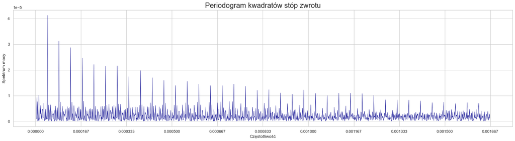

```python
fig, ax = plt.subplots(figsize=(25, 6))
plt.plot(freq[1:n//2], sqrt_power_spectrum[1:n//2], linewidth=0.7, color="darkblue")
plt.xticks(np.arange(0, 1 / (5 * 60) / 2, 1 / (5 * 60 * 10) / 2))
plt.xlabel('Częstotliwość')
plt.ylabel('Spektrum mocy')
plt.title('Periodogram kwadratów stóp zwrotu', size=20)
plt.show()
```

### 4.3.2. Częstotliwości dominujące

Z powyższego periodogramu pobrano 10 dominujących częstotliwości i przekształcono w celu otrzymania dominujących okresów. Okazało się, że periodogram dla kwadratów stóp zwrotu wskazał jako dominujące okresy dokładnie te same wartości co periodogram dla wartości bezwzględnych stóp. Niewielkie różnice we wskazaniach między periodogramami pojawiają się dopiero około 8 najbardzej dominującej częstotlwiości. 5 najważniejszych okresów w tym przypadku jest dokładnie taka sama jak powyżej:

```python
max_indices = np.argsort(sqrt_power_spectrum[1:n//2])[-10:]
max_indices = np.flip(max_indices)

# get the corresponding frequencies for the dominant peaks
dominant_frequencies = freq[max_indices]

for i, freq_index in enumerate(max_indices):
    power_value = sqrt_power_spectrum[freq_index]
    print(f"Częstotliwość dominująca {i+1}: {dominant_frequencies[i]:.5f}; "
          f"Okres: {1 / dominant_frequencies[i] / 60 / 60:.3f} godz. = {1 / dominant_frequencies[i] / 60:.3f} min.")
```

```
Częstotliwość dominująca 1: 0.00004; Okres: 6.686 godz. = 401.176 min.
Częstotliwość dominująca 2: 0.00008; Okres: 3.295 godz. = 197.681 min.
Częstotliwość dominująca 3: 0.00013; Okres: 2.186 godz. = 131.154 min.
Częstotliwość dominująca 4: 0.00017; Okres: 1.635 godz. = 98.129 min.
Częstotliwość dominująca 5: 0.00021; Okres: 1.307 godz. = 78.391 min.
Częstotliwość dominująca 6: 0.00030; Okres: 0.932 godz. = 55.902 min.
Częstotliwość dominująca 7: 0.00026; Okres: 1.088 godz. = 65.263 min.
Częstotliwość dominująca 8: 0.00038; Okres: 0.724 godz. = 43.439 min.
Częstotliwość dominująca 9: 0.00034; Okres: 0.815 godz. = 48.889 min.
Częstotliwość dominująca 10: 0.00043; Okres: 0.651 godz. = 39.083 min.
```

# 5. Wyodrębnianie składowych

W kolejnej części projektu dla szeregów czasowych wartości bezwzględnych i kwadratów stóp zwrotu zastosować filtry dolno- oraz górnoprzepustowe w celu wyodrębnienia składowych o okresach krótszych oraz dłuższych niż jedna sesja (jeden dzień).

```python
day_freq_index = np.where((1 / freq / 60 / 60) > 8)[0][-1]
day_freq_index
```

```
28
```

Procedura wyodrębniania odpowiednich składowych z szeregu wyglądała następująco:

1. Wyznaczenie **transformaty Fourier'a** dla wszystkich rozważanych częstotliwości.
2. **Nałożenie filtru** dolno- lub górnoprzepustowego (poprzez wyzerowanie wartości dla częstotliwości powyej lub poniżej długości trwania jednej sesji).
3. Wyznaczenie **odwrotnej transformaty Fourier'a** - wartości szeregu po odfiltrowaniu odpowiednich częstotliwości.

Dla każdego z szeregów w pierwszej kolejności zastosowano **filtr górnoprzepustowy**. Ten rodzaj filtru dopuszcza składowe o wysokiej częstotliwości - większe niż częstotliwość graniczna i odrzuca wszystkie inne niepożądane składowe częstotliwości sygnału. Dzięki temu w szeregu pozostają jedynie składowe **krótkookresowe** (ponieważ za nie odpowiadają wysokie częstotliwości).

W celu wyodrębnienia składowych **długookresowych** w szeregu casowym, na szeregi nałożono **filtr dolnoprzepustowy**, który ma zdolność tłumienia składników o wysokiej częstotliwości w danych i pozostawiania jedynie składników o niskiej częstotliwości sygnału (odpowiedzialne za składowe długookresowe).

## 5.1. Wartości bezwzględne stóp zwrotu

### 5.1.1. Składowe krótkookresowe

Poniżej znajduje się wykres wartości bezwzględnych stóp zwrotu przed i po nałożeniu filtra górnoprzepsutowego. Filtr ten stłumił składowe długookresowe i pozostawił składowe krótkookresowe w szeregu.

Można zauważyć, że szereg po nałożeniu filtra wygląda bardzo podobnie do szeregu wyjściowego, co może świadczyć o tym, że wartości stóp są kształtowane przede wszystkim przez składowe krótkookresowe. Jest to zrozumiałe, ponieważ zwroty z akcji często charakteryzują się krótkoterminową zmiennością i wahaniami wynikającymi z takich czynników, jak nastroje rynkowe, wydarzenia informacyjne lub transakcje w ciągu dnia.

Dodatkowo, szereg wartości bezwzględnych po nałożeniu filtra może przyjmować ujemne wartości. Można zatem wywnioskować, że składowe długookresowe odpowiadają za lekkie podwyższenie wartości na całej długości szregu.

```python
# nałożenie filtra górnoprzepsutowego
short_abs_returns_fft = abs_returns_fft.copy()

short_abs_returns_fft[:day_freq_index] = 0
short_abs_returns_fft[-day_freq_index:] = 0

# obliczanie gęstości spektralnej (periodogramu)
short_abs_power_spectrum = np.abs(short_abs_returns_fft) ** 2

# odwrotna transformata Fourier'a
short_abs_returns_ifft = np.fft.ifft(short_abs_returns_fft)
```

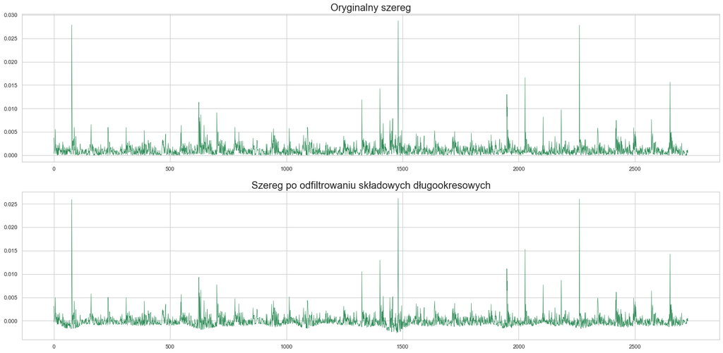

```python
fig, ax = plt.subplots(2, 1, figsize=(25, 12))

# ax[0].plot(freq[1:n//2], short_abs_power_spectrum[1:n//2], linewidth=0.7, color="seagreen")
# ax[0].set_xticks(np.arange(0, 1 / (5 * 60) / 2, 1 / (5 * 60 * 10) / 2))
# ax[0].set_xlabel('Częstotliwość')
# ax[0].set_ylabel('Spektrum mocy')
# ax[0].set_title('Periodogram wartości bezwzględnych stóp po zastosowaniu filtru górnoprzepustowego', size=20)

ax[0].plot(range(0, len(df)), df["abs_log_return"], linewidth=0.7, color="seagreen")
ax[0].set_title('Oryginalny szereg', size=20)

ax[1].plot(range(0, len(df)), short_abs_returns_ifft, linewidth=0.7, color="seagreen")
ax[1].set_title('Szereg po odfiltrowaniu składowych długookresowych', size=20)

plt.show()
```

### 5.1.2. Składowe długookresowe

Poniżej znajduje się wykres wartości bezwzględnych stóp zwrotu przed i po nałożeniu filtra dolnoprzepsutowego. Filtr pozostawił w szeregu składowe długookresowe i odfiltrował składowe krótkookresowe.

Na podstawie wykresu można stwierdzić, że składowe długookresowe (powyżej długości trwania jednej sesji) mają niewielki wpływ na to, jak kształtuje się szereg wartości bezwzględnych stóp. Udział wolniejszych trendów długoterminowych w całkowitej zmienności szeregu jest znikomy.

```python
# nałożenie filtra dolnoprzepsutowego
long_abs_returns_fft = abs_returns_fft.copy()

long_abs_returns_fft[day_freq_index:-day_freq_index] = 0

# obliczanie gęstości spektralnej (periodogramu)
long_abs_returns_spectrum = np.abs(long_abs_returns_fft) ** 2

# odwrotna transformata Fourier'a
long_abs_returns_ifft = np.fft.ifft(long_abs_returns_fft)
```

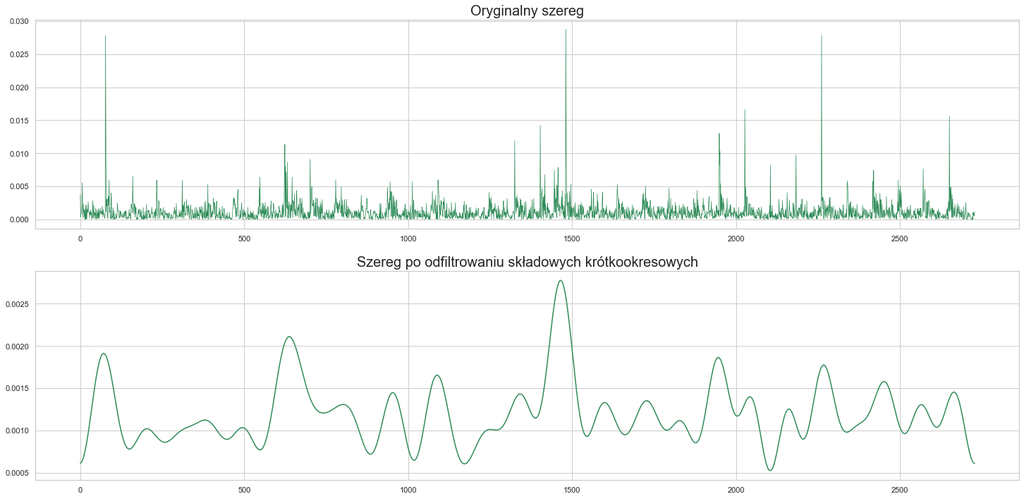

```python
fig, ax = plt.subplots(2, 1, figsize=(25, 12))

ax[0].plot(range(0, len(df)), df["abs_log_return"], linewidth=0.7, color="seagreen")
ax[0].set_title('Oryginalny szereg', size=20)

ax[1].plot(range(0, len(df)), long_abs_returns_ifft, color="seagreen")
ax[1].set_title('Szereg po odfiltrowaniu składowych krótkookresowych', size=20)

plt.show()
```

## 5.2. Kwadraty stóp zwrotu

W celu wyodrębnienia składowych krótko- i długookresowych dla szeregu kwadratów stóp zwrotu dokonano analogicznych przekształceń co powyżej.

Na podstawie wykresów można stwierdzić, że wartości stóp są kształtowane przede wszystkim przez składowe krótkookresowe - dominujące wzorce w danych są głównie napędzane przez składowe o wysokiej częstotliwości. Z kolei składowe długookresowe mają niewielki wpływ na to, jak kształtuje się szereg kwadratów stóp. Kwadraty zwrotów z akcji wynikają przede wszystkim z czynników krótkoterminowych, a nie z długoterminowych trendów.

### 5.2.1. Składowe krótkookresowe

```python
# nałożenie filtra górnoprzepsutowego
short_sqrt_returns_fft = sqrt_returns_fft.copy()

short_sqrt_returns_fft[:day_freq_index] = 0
short_sqrt_returns_fft[-day_freq_index:] = 0

# obliczanie gęstości spektralnej (periodogramu)
short_sqrt_power_spectrum = np.abs(short_sqrt_returns_fft) ** 2

# odwrotna transformata Fourier'a
short_sqrt_returns_ifft = np.fft.ifft(short_sqrt_returns_fft)
```

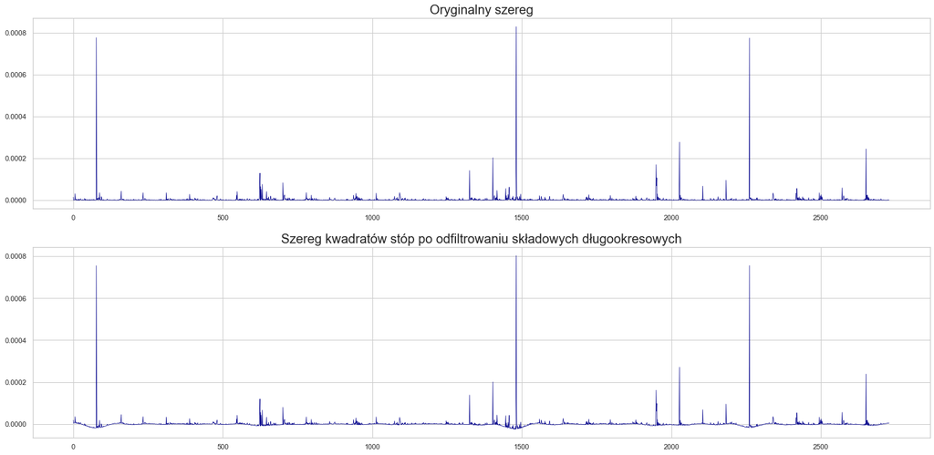

```python
fig, ax = plt.subplots(2, 1, figsize=(25, 12))

# ax[0].plot(freq[1:n//2], short_sqrt_power_spectrum[1:n//2], linewidth=0.7, color="darkblue")
# ax[0].set_xticks(np.arange(0, 1 / (5 * 60) / 2, 1 / (5 * 60 * 10) / 2))
# ax[0].set_xlabel('Częstotliwość')
# ax[0].set_ylabel('Spektrum mocy')
# ax[0].set_title('Periodogram kwadratów stóp po zastosowaniu filtru górnoprzepustowego', size=20)

ax[0].plot(range(0, len(df)), df["sqrt_log_return"], linewidth=0.7, color="darkblue")
ax[0].set_title('Oryginalny szereg', size=20)

ax[1].plot(range(0, len(df)), short_sqrt_returns_ifft, linewidth=0.7, color="darkblue")
ax[1].set_title('Szereg kwadratów stóp po odfiltrowaniu składowych długookresowych', size=20)

plt.show()
```

### 5.2.2. Składowe długookresowe

```python
# nałożenie filtra dolnoprzepsutowego
long_sqrt_returns_fft = sqrt_returns_fft.copy()

long_sqrt_returns_fft[day_freq_index:-day_freq_index] = 0

# obliczanie gęstości spektralnej (periodogramu)
long_sqrt_returns_spectrum = np.abs(long_sqrt_returns_fft) ** 2

# odwrotna transformata Fourier'a
long_sqrt_returns_ifft = np.fft.ifft(long_sqrt_returns_fft)
```

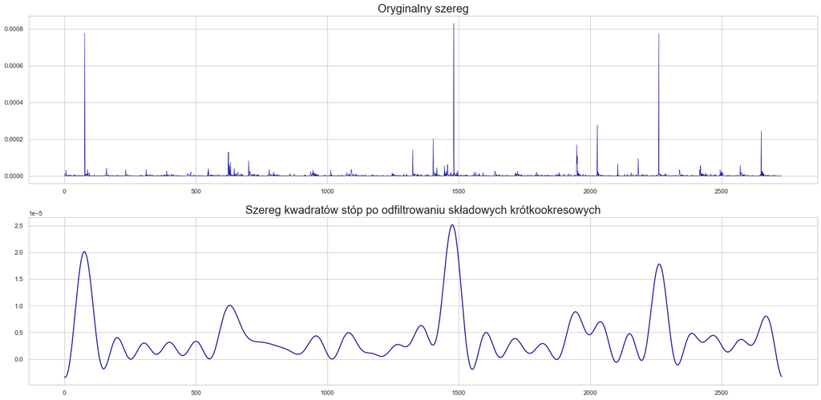

```python
fig, ax = plt.subplots(2, 1, figsize=(25, 12))

ax[0].plot(range(0, len(df)), df["sqrt_log_return"], linewidth=0.7, color="darkblue")
ax[0].set_title('Oryginalny szereg', size=20)

ax[1].plot(range(0, len(df)), long_sqrt_returns_ifft, color="darkblue")
ax[1].set_title('Szereg kwadratów stóp po odfiltrowaniu składowych krótkookresowych', size=20)

plt.show()
```

# 6. Wnioski

W niniejszym projekcie badano powtarzające się wzroce w szeregu stóp zwrotu spółki Alphabet, na której portfel składa się między innymi Google. W tym celu za pomocą korelogramu oraz periodogramu analizowano logarytmiczne stopy zwrotu spółki, ich wartości bezwzględne oraz kwadraty. Następnie, w celu określenia wpływu składowych krótko- i długookresowych na szereg, zastosowano filtry dolno- oraz górnoprzepustowy.

Analiza korelogramów pozwoliła zaobserwować następujące prawidłowości:

Analiza szeregów po nałożeniu filtrów pozwoliła wyciagnąć następujące wnioski:

1. Zwroty z akcji wynikają przede wszystkim z czynników krótkoterminowych, a nie z długoterminowych trendów. Składowe o wysokiej częstotliwości dominują w ogólnym zachowaniu stóp zwrotu.
2. Ceny akcji szybko dostosowują się, co utrudnia identyfikację trwałych trendów długoterminowych, a co za tym idzie, przewidywanie przyszłych ruchów cen.